# Techniki Wizualizacji Danych - PD5

Adam Rydelek

19 listopada 2018

# Wprowadzenie

Na potrzeby pracy domowej numer 5 wykonałem ankietę (link do ankiety: https://goo.gl/forms/zKUFPfcnbXWFNFCT2), która sprawdzała różnice w odbiorze tych samych danych przedstawionych na różnych wykresach. Głównym celem było porównanie przydatności wykresów kołowych w wizualizacji danych i porównanie ich z wykresami słupkowymi. Grupą ankietowaną byli moi koledzy i koleżanki z liceum, czyli młodzi ludzie, którzy są obeznani z odbiorem różnego rodzaju wykresów. Łącznie na ankietę odpowiedziało 20 osób, w tym 11 mężczyzn i 9 kobiet. Ankietowani musieli odpowiedzieć na cztery pytania po obejrzeniu każdego z trzech wykresóW, a brzmiały one:

1. Które miasto jest największe?
2. Które miasto jest najmniejsze?
3. Które miasto ma większą powierzchnię, Wrocław, czy Łódź?
4. Które miasto ma większą powierzchnię, Wrocław, czy Gdańsk?

# Wizualizacja danych

Dane, które postanowiłem przedstawić pochodzą z portalu www.wroclaw.pl, gdzie przedstawiony został wykres porównujący powierzchnię Wrocławia na tle innych miast w Polsce. Dane przedstawiłem na trzech wykresach: dwóch kołowych i jednym słupkowym.

## Wykres 1

Pierwszym przedstawionym w ankieie był wykres kołowy pochodzący ze strony www.wroclaw.pl, nazywany później przeze mnie “Wykresem kołowym 1”.

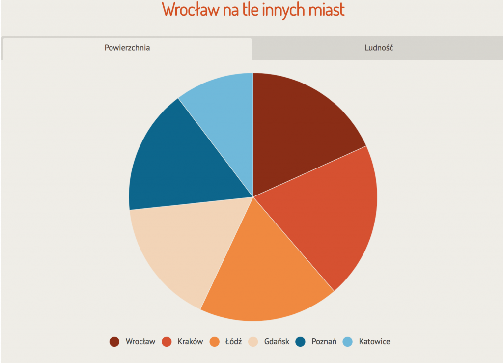

## Wykres 2

Drugi wykres był moją próbą poprawienia wykresu kołowego numer 1, jednak bez zmiany rodzaju wykresu, czyli jest to również wykres kołowy, jednak z sensowną kolejnością przedstawionych miast i spójnym doborem kolorów, oraz wyróżnieniem Wrocławia, który jednak jest gwiazdą tego wykresu.

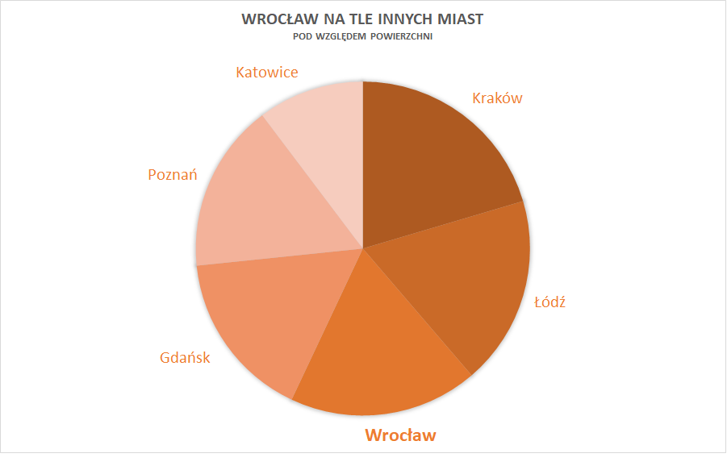

## Wykres 3

Trzeci wykres to wykres słupkowy, który przedstawia te same dane.

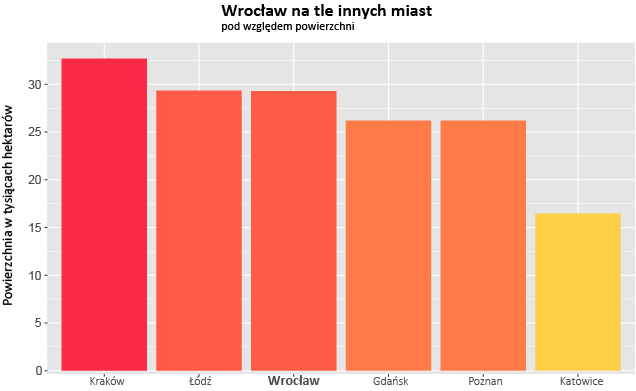

# Odpowiedzi na pierwsze pytanie:

## Które miasto jest największe?

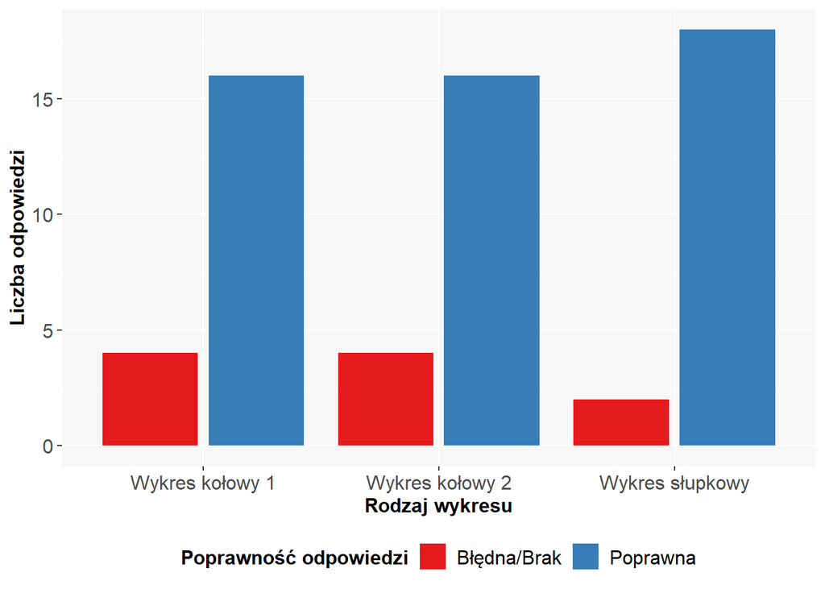

Można na podstawie tych odpowiedzi wywnioskować, że określenie największego miasta nie sprawiło większych trudności nawet przy wykresach kołowych, jednak widać, że najwięcej poprawnych odpowiedzi było przy wykresie słupkowym.

# Odpowiedzi na drugie pytanie:

## Które miasto jest najmniejsze?

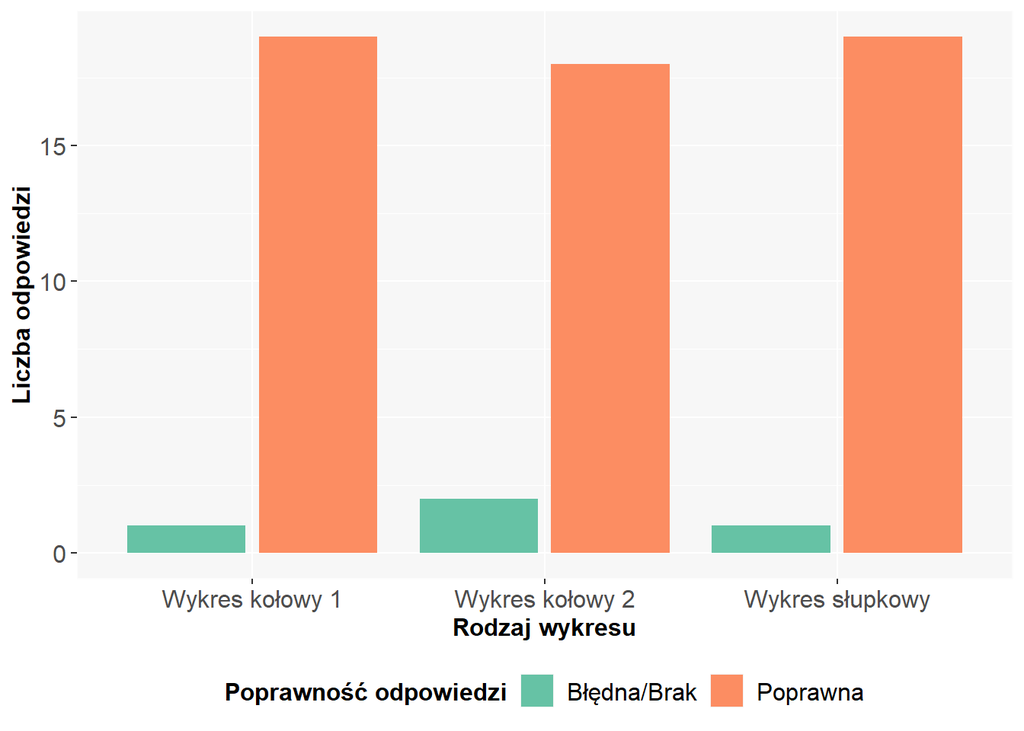

Przy określaniu najmniejszego miasta, była tak duża różnica powierzchni między nim, a resztą miast, że na podstawie każdego wykresu znaczna większość badanych odpowiedziała poprawnie, więc do tego celu wykres słupkowy nie był w zupełności potrzebny.

# Odpowiedzi na trzecie pytanie

## Które miasto ma większą powierzchnię, Wrocław, czy Łódź?

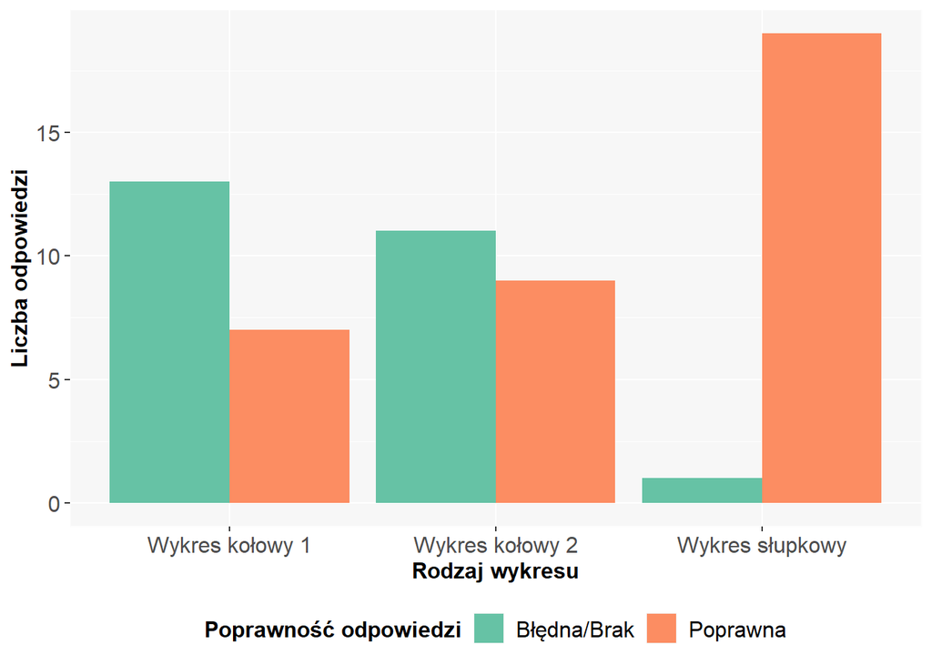

Jak można zaobserwować na powyższym wykresie, przy porównywaniu dwóch bliskich siebie powierzchnią miast poprawność odpowiedzi w obu wykresach kołowych diametralnie spadła. Człowiek ma problem z porównaniem powierzchni dwóch bardzo podobnych wycinków koła, a łatwiej mu określić róznicę długości dwóch słupków stojących przy sobie. Drugi wykres kołowy zapewnił poprawę względem pierwszego dzięki odpowiedniego zastosowania skali kolorów.

# Odpowiedzi na czwarte pytanie

## Które miasto ma większą powierzchnię, Wrocław, czy Gdańsk?

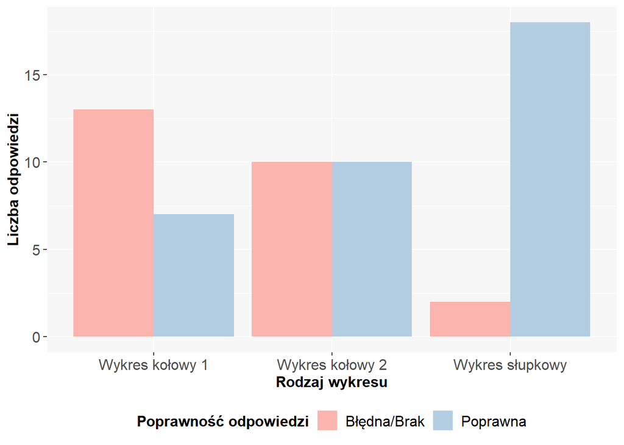

W przypadku czwartego pytania, zachowanie było bardzo podobne jak w trzecim pytanie, jednak jeszcze bardziej uwidoczniła się różnica w zastosowaniu odpowiedniej skali kolorów i kolejności występowania miast, ponieważ w wykresie kołowym 2 aż 50% ankietowanych odpowiedziało poprawnie. Bez zaskoczeń, najwięcej poprawnych odpowiedzi było po obejrzeniu wykresu słupkowego.

# Podsumowanie

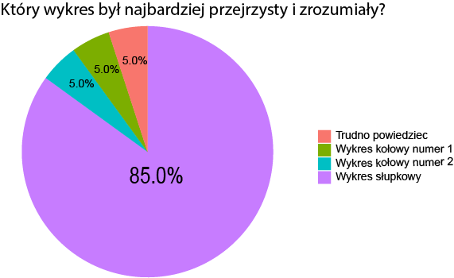

Na podstawie odpowiedzi na ostatnie pytanie widać, że aż 85% ankietowanych uznało wykres słupkowy za najbardziej przejrzysty, zrozumiały. Dane te przedstawiłem jednak za pomocą wykresu kołowego i są one jasne, oraz czytelne. Jaki więc można wyciągnąć z tego wniosek?

1. Przy porównywaniu bliskich sobie wartości wykres słupkowy sprawdzi się o wiele lepiej od kołowego
2. Przy pokazywaniu dominacji pewnej wartości nad resztą oba rodzaje wykresów są równie czytelne
3. Dobre zastosowanie kolorów pomaga w poprawnym odbiorze informacji z wykresu
4. Poprawna kolejność występowania wartości umożliwia odczytanie dodatkowych informacji